# cc_defaults

Lets explore logistic regression. I'll use a dataset of credit card defaults in Taiwan, available from the UCI Machine Learning Repository archive.ics.uci.edu/ml/datasets/default+of+credit+card+clients

```python
import matplotlib.pyplot as plt
import numpy as np
import pandas as pd
import seaborn as sns
from sklearn.compose import ColumnTransformer, make_column_transformer
from sklearn.linear_model import LogisticRegression
from sklearn.metrics import confusion_matrix, classification_report, roc_curve, roc_auc_score
from sklearn.model_selection import train_test_split
from sklearn.preprocessing import OneHotEncoder
```

Thanks to scikit-learn, I guess?

```python
sns.set()
%matplotlib inline
plt.rcParams['figure.dpi'] = 150
plt.rcParams['figure.figsize'] = (8,5)
```

```python
data = pd.read_csv("default_of_credit_card_clients.csv", index_col="ID")
```

Our aim is to predict whether the customers will default. This detail is stored in the field 'default'. Let's see how many instances we have of each outcome:

```python
data.default.value_counts()
```

```
0    23364
1     6636
Name: default, dtype: int64
```

That should be plenty. If we had only a small number of samples of one outcome, we'd have to look at upsampling.

Go ahead, do some visualisation. I can see you eyeing matplotlib. Explore that data, I'll wait.

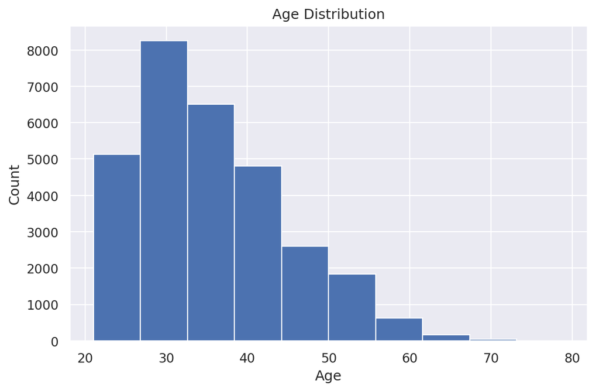

```python
data.AGE.hist()
plt.title("Age Distribution")
plt.xlabel("Age")
plt.ylabel("Count")
plt.show()
```

Q: Was that just an excuse to get more visual content into the notebook?

A: HOW DARE YOU.

Our numeric columns have vastly different ranges (e.g. Age and credit limit). While this won't necessarily be a problem mathematically, it can make the results harder to interpret. As a result we'll standardise the numeric columnns around a mean of $0$:

```python
cols_to_normalise = ["LIMIT_BAL", "AGE", "PAY_0", "PAY_2", "PAY_3", "PAY_4", "PAY_5", "PAY_6",
                     "BILL_AMT1", "BILL_AMT2", "BILL_AMT3", "BILL_AMT4", "BILL_AMT5", "BILL_AMT6",
                     "PAY_AMT1", "PAY_AMT2", "PAY_AMT3", "PAY_AMT4", "PAY_AMT5", "PAY_AMT6"]
data[cols_to_normalise] = data[cols_to_normalise].apply(lambda x: (x - np.mean(x))/np.std(x))
```

We're going to convert the categorical columns to dummy later, but for now let's replace the integer values with their actual meanings, to make the data easier to interpret:

```python
sexdict = {1:"Male", 2:"Female"}
data.SEX = data.SEX.replace(sexdict)
edudict = {1: "Graduate School", 2:"University", 3:"High School", 4:"Other Education", 5:"Other Education", 6:"Other Education", 0:"Other Education"}
data.EDUCATION = data.EDUCATION.replace(edudict)
mardict = {1:"Married", 2:"Single", 3:"Other Status", 0:"Other Status"}
data.MARRIAGE = data.MARRIAGE.replace(mardict)
```

Checking the data to see what else needs doing:

```python
data.head()
```

| ID | LIMIT_BAL | SEX | EDUCATION | MARRIAGE | AGE | PAY_0 | PAY_2 | PAY_3 | PAY_4 | PAY_5 | ... | BILL_AMT4 | BILL_AMT5 | BILL_AMT6 | PAY_AMT1 | PAY_AMT2 | PAY_AMT3 | PAY_AMT4 | PAY_AMT5 | PAY_AMT6 | default |
| --- | --- | --- | --- | --- | --- | --- | --- | --- | --- | --- | --- | --- | --- | --- | --- | --- | --- | --- | --- | --- | --- |
| 1 | -1.136720 | Female | University | Married | -1.246020 | 1.794564 | 1.782348 | -0.696663 | -0.666599 | -1.530046 | ... | -0.672497 | -0.663059 | -0.652724 | -0.341942 | -0.227086 | -0.296801 | -0.308063 | -0.314136 | -0.293382 | 1 |
| 2 | -0.365981 | Female | University | Single | -1.029047 | -0.874991 | 1.782348 | 0.138865 | 0.188746 | 0.234917 | ... | -0.621636 | -0.606229 | -0.597966 | -0.341942 | -0.213588 | -0.240005 | -0.244230 | -0.314136 | -0.180878 | 1 |
| 3 | -0.597202 | Female | University | Single | -0.161156 | 0.014861 | 0.111736 | 0.138865 | 0.188746 | 0.234917 | ... | -0.449730 | -0.417188 | -0.391630 | -0.250292 | -0.191887 | -0.240005 | -0.244230 | -0.248683 | -0.012122 | 0 |
| 4 | -0.905498 | Female | University | Married | 0.164303 | 0.014861 | 0.111736 | 0.138865 | 0.188746 | 0.234917 | ... | -0.232373 | -0.186729 | -0.156579 | -0.221191 | -0.169361 | -0.228645 | -0.237846 | -0.244166 | -0.237130 | 0 |
| 5 | -0.905498 | Male | University | Married | 2.334029 | -0.874991 | 0.111736 | -0.696663 | 0.188746 | 0.234917 | ... | -0.346997 | -0.348137 | -0.331482 | -0.221191 | 1.335034 | 0.271165 | 0.266434 | -0.269039 | -0.255187 | 0 |

5 rows × 24 columns

The **PAY_x** columns should be categorical really. We'll ensure they're all positive-valued first:

```python
pay_cols = ["PAY_0", "PAY_2", "PAY_3", "PAY_4", "PAY_5", "PAY_6"]
data[pay_cols] = data[pay_cols].apply(lambda x: x + 2)
```

And split our columns into independent and dependent variables:

```python
X = data.iloc[:,0:23]
y = data.default
```

We need to convert our categorical columns to a series of binary columns or dummy columns. Thanks to StackExchange for this solution, passing the indices of the columns to convert to a pair of sklearn functions:

```python
preprocessor = make_column_transformer((OneHotEncoder(),[1, 2, 3, 5, 6, 7, 8, 9, 10]),remainder="passthrough")
X = preprocessor.fit_transform(X)
```

And now we're ready to divide up the data into training and testing sets:

```python
X_train, X_test, y_train, y_test = train_test_split(X, y, test_size=0.3)
```

After all that wrangling, training the model is very simple with sklearn:

```python
log_model = LogisticRegression(solver='liblinear', random_state=7734)
log_model.fit(X_train, y_train)
```

```
LogisticRegression(C=1.0, class_weight=None, dual=False, fit_intercept=True,
          intercept_scaling=1, max_iter=100, multi_class='warn',
          n_jobs=None, penalty='l2', random_state=7734, solver='liblinear',
          tol=0.0001, verbose=0, warm_start=False)
```

How does it perform?

```python
y_pred = log_model.predict(X_test)
print("Accuracy: ", log_model.score(X_test, y_test))
```

```
Accuracy:  0.8226666666666667
```

Let's check a confusion matrix for the actual number of errors in our model's predictions:

```python
confusion_matrix = confusion_matrix(y_test, y_pred)
print(confusion_matrix)
```

```
[[6694  326]
 [1270  710]]
```

More statistics are available:

```python
print(classification_report(y_test, y_pred))
```

```
              precision    recall  f1-score   support

           0       0.84      0.95      0.89      7020
           1       0.69      0.36      0.47      1980

   micro avg       0.82      0.82      0.82      9000
   macro avg       0.76      0.66      0.68      9000
weighted avg       0.81      0.82      0.80      9000
```

To finish, let's display the ROC curve. It's a pretty intuitive visualisation of our model's value:

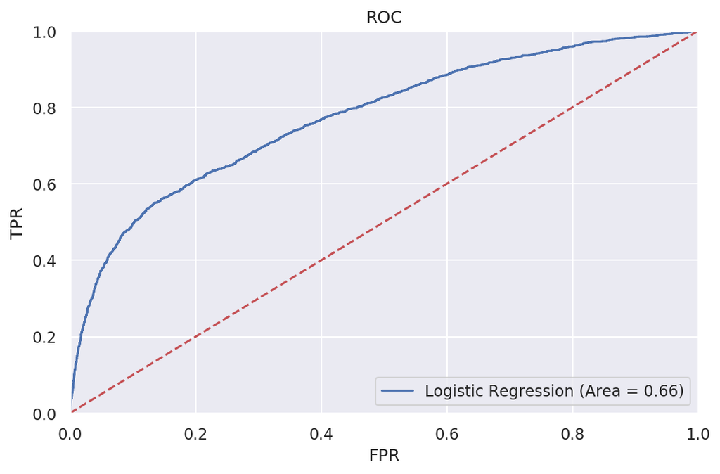

```python
log_model_auc = roc_auc_score(y_test, log_model.predict(X_test))
fpr, tpr, thresholds = roc_curve(y_test, log_model.predict_proba(X_test)[:,1])
plt.plot(fpr, tpr, label="Logistic Regression (Area = %0.2f)" %log_model_auc)
plt.plot([0,1],[0,1], "r--")
plt.legend(loc="lower right")
plt.title("ROC")
plt.xlabel("FPR")
plt.ylabel("TPR")
plt.xlim([0.0, 1.0])
plt.ylim([0.0, 1.0])
plt.show()
```

The Area Under Curve isn't great, but it's not bad for a quick demonstration. A possible positive - depending on the situation - is the False Positive Rate is penalised more than the True Positive Rate is rewarded, as revealed by the left-skewed curve.